# Logistic Regression Analysis

Anthony Wen

2024-03-13

# Introduction (4 points)

```r
# You can feel free to modify this line to read the data in
#  as you will only be submitting a completed PDF
loanDefaultData<-read.csv("LoanDefaultData.csv")
```

In this study we will look at the different variables or characteristics of the people that will potentially request loans to determine whether or not a bank should grant their loan. In other words, it is for predicting loan default, whether a machine will say yes or no to someone requesting a loan. The data that was submitted had information such as the person’s marital status, credit score and other variables that might have an impact on the person’s loan default. This study would analyze if such variables would impact a person’s loan default, just as the original study has also intended to predict with a special emphasis (out of personal interest) on whether there was evidence that default were impacted by the marital status or highest education level of the applicant.

# The Variables (8 points)

The variables available for this analysis are:

### Response:

- Default (binary/Catagorical): This records whether or not the loan was defaulted on. It is the variable that we seek to predict in our logistic regression model。

```r
table(loanDefaultData$Default)
```

```
##
##    0    1
## 3091  409
```

### Predictors:

```r
names(loanDefaultData)
```

```
##  [1] "Age"            "Income"         "LoanAmount"     "CreditScore"
##  [5] "MonthsEmployed" "NumCreditLines" "InterestRate"   "LoanTerm"
##  [9] "Education"      "EmploymentType" "MaritalStatus"  "HasCoSigner"
## [13] "Default"
```

```r
mean(loanDefaultData$Age)
```

```
## [1] 43.74314
```

```r
sd(loanDefaultData$Age)
```

```
## [1] 14.95721
```

```r
range(loanDefaultData$Age)
```

```
## [1] 18 69
```

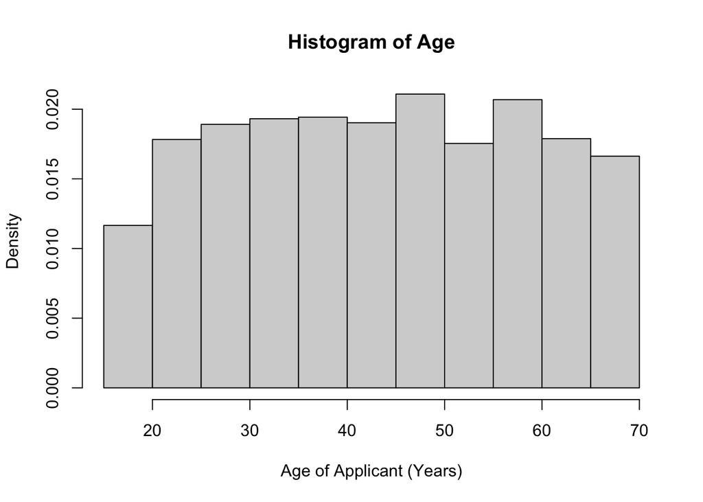

```r
hist(loanDefaultData$Age, main='Histogram of Age', xlab='Age of Applicant (Years)', freq=FALSE)
```

- Income (numeric): a numeric variable that tells us an applicant’s annual income in USD. It has mean of 82351.62 or around 82 thousand USD of annual income and a standard deviation of 39177.07 USD.

```r
mean(loanDefaultData$Income)
```

```
## [1] 82351.62
```

```r
sd(loanDefaultData$Income)
```

```
## [1] 39177.07
```

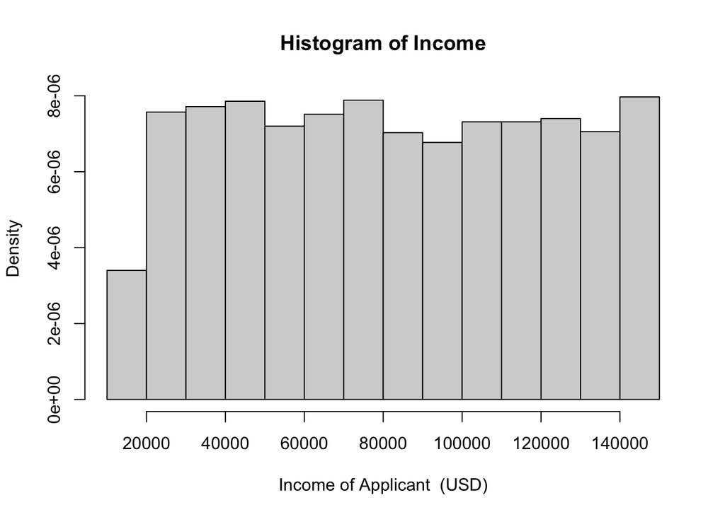

```r
hist(loanDefaultData$Income, main='Histogram of Income', xlab='Income of Applicant  (USD)', freq=FALSE)
```

- LoanAmount (numeric): a numeric variable that tells us the loan amount requested by the applicant in USD or the amount of money that is being borrowed. It has mean of 128733.5 or around 129 thousand USD of annual income and a standard deviation of 70830.42 USD. The mean of the loan is much larger than the mean of the applicant’s annual income, which shows how people are usually borrowing more money than they are making.

```r
mean(loanDefaultData$LoanAmount)
```

```
## [1] 128733.5
```

```r
sd(loanDefaultData$LoanAmount)
```

```
## [1] 70830.42
```

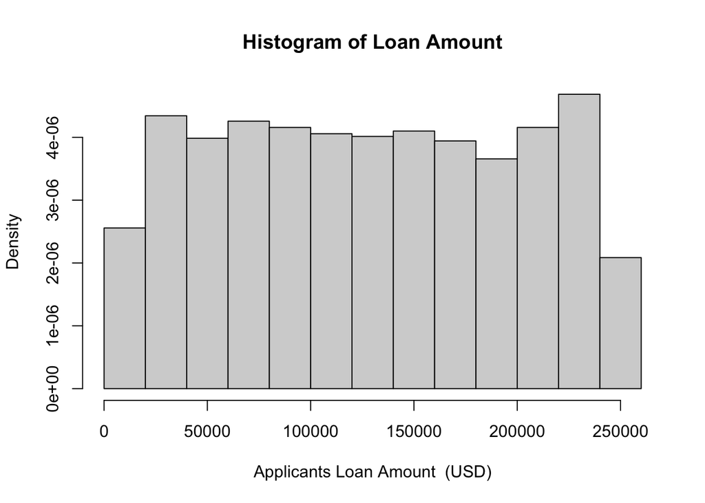

```r
hist(loanDefaultData$LoanAmount, main='Histogram of Loan Amount', xlab='Applicants Loan Amount  (USD)', freq=FALSE)
```

- CreditScore (numeric): a numeric variable that tells us the applicant’s credit score to tell audience a applicant’s creditworthiness. It has mean of 575.0686 or around 575 points/credit score and a standard deviation of 159.4175 or 159 points. The variability suggests a diverse set of credit scores among the applicants.

```r
mean(loanDefaultData$CreditScore)
```

```
## [1] 575.0686
```

```r
sd(loanDefaultData$CreditScore)
```

```
## [1] 159.4175
```

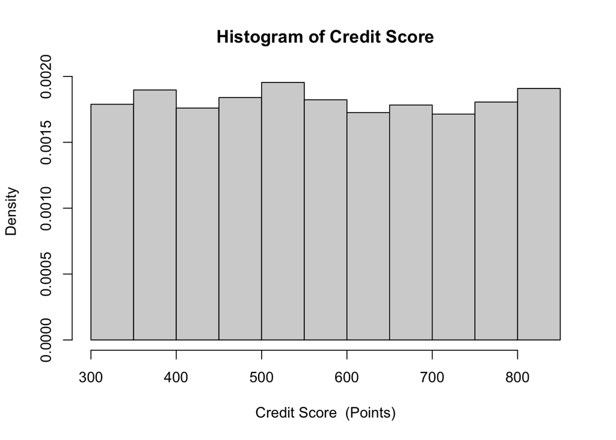

```r
hist(loanDefaultData$CreditScore, main='Histogram of Credit Score', xlab='Credit Score  (Points)', freq=FALSE)
```

- MonthsEmployed (numeric): a numeric variable that tells us the number of months the applicant has been employed. It has mean of 60.15971 months or around 5 years of being employed and a standard deviation of 34.10338 months or almost 3 years.

```r
mean(loanDefaultData$MonthsEmployed)
```

```
## [1] 60.15971
```

```r
sd(loanDefaultData$MonthsEmployed)
```

```
## [1] 34.10338
```

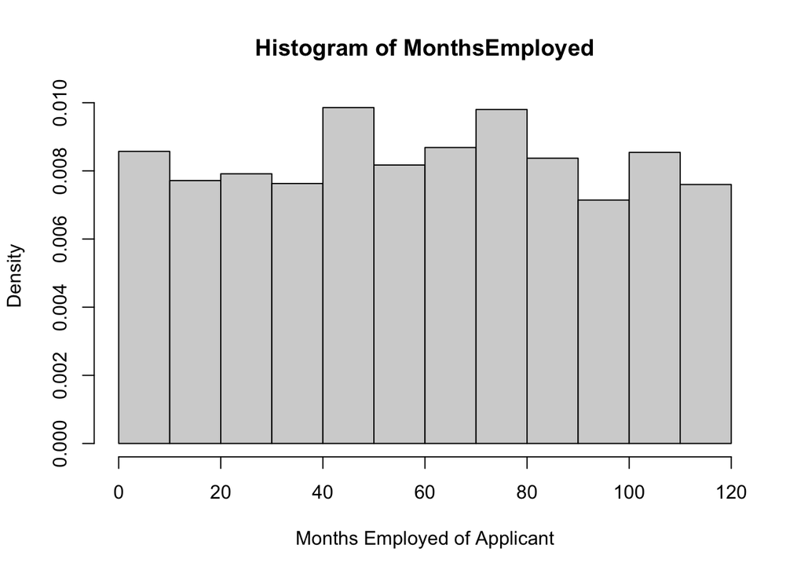

```r
hist(loanDefaultData$MonthsEmployed, main='Histogram of MonthsEmployed', xlab='Months Employed of Applicant', freq=FALSE)
```

- NumCreditLines (numeric): a numeric variable that tells us the number of credit lines the applicant has opened. It has mean of 2.47 lines (around 2 lines opened) and a standard deviation of 1.115464 lines (basically 1 line).

```r
mean(loanDefaultData$NumCreditLines)
```

```
## [1] 2.469143
```

```r
sd(loanDefaultData$NumCreditLines)
```

```
## [1] 1.115464
```

```r
table(loanDefaultData$NumCreditLines)
```

```
##
##   1   2   3   4
## 901 896 863 840
```

- InterestRate (numeric): a numeric variable that tells us the interest rate of the loan.It has mean of 13.61331% interest rate and a standard deviation of 6.661623% interest.

```r
mean(loanDefaultData$InterestRate)
```

```
## [1] 13.61331
```

```r
sd(loanDefaultData$InterestRate)
```

```
## [1] 6.661623
```

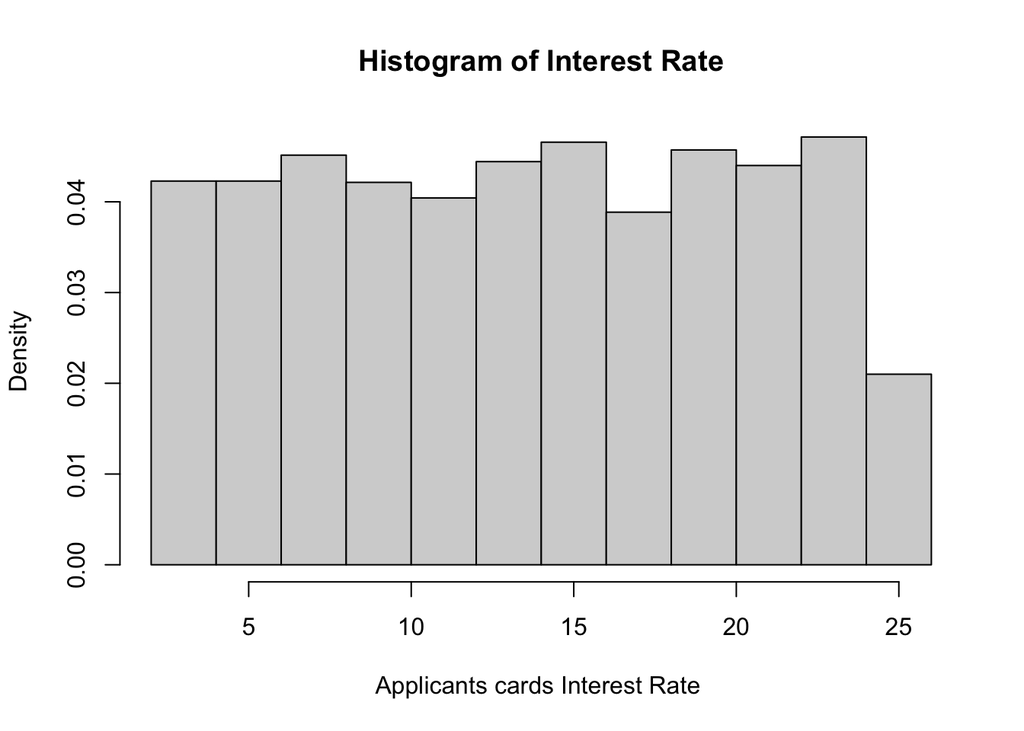

```r
hist(loanDefaultData$InterestRate, main='Histogram of Interest Rate', xlab='Applicants cards Interest Rate ', freq=FALSE)
```

- LoanTerm (numeric): a numeric variable that tells us the length of term of the loan in months. It has mean of 36.04457 months or around 3 years of length for the loan terms and a standard deviation of 16.94259 months or almost 1.5 years.

```r
mean(loanDefaultData$LoanTerm)
```

```
## [1] 36.04457
```

```r
sd(loanDefaultData$LoanTerm)
```

```
## [1] 16.94259
```

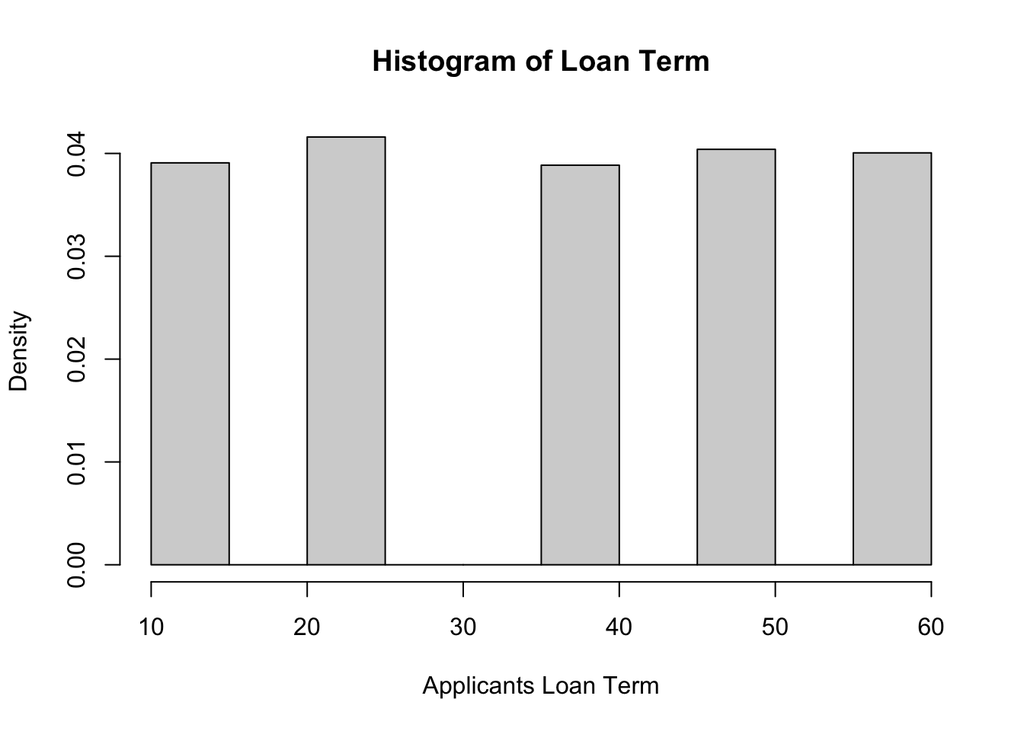

```r
hist(loanDefaultData$LoanTerm, main='Histogram of Loan Term', xlab='Applicants Loan Term', freq=FALSE)
```

- Education (categorical): a categorical variable that tells us the highest level of education attained by the applicant. The number of applicants in each catagory are pretty similar, aka the standard deviation is not very high.

```r
table(loanDefaultData$Education)
```

```
##
##  Bachelor's High School    Master's         PhD
##         902         849         893         856
```

- EmploymentType (Categorical): a catagorical variable that tells us the type of employment of the applicant. The number of applicants in each catagory are pretty similar, aka the standard deviation is not very high.

```r
table(loanDefaultData$EmploymentType)
```

```
##
##     Full-time     Part-time Self-employed    Unemployed
##           872           873           908           847
```

- MaritalStatus (Categorical): a catagorical variable that tells us the marital status of the applicant. It’s split into single, married, or divorced. The number of applicants in each catagory are pretty similar, aka the standard deviation is not very high.

```r
table(loanDefaultData$MaritalStatus)
```

```
##
## Divorced  Married   Single
##     1176     1126     1198
```

- HasCoSigner (binary/Categorical): a catagorical variable that tells us whether the loan application has a cosigner. It is a yes or no value.

```r
table(loanDefaultData$HasCoSigner)
```

```
##
##   No  Yes
## 1744 1756
```